# Computer Practical 5: Data analysis and manipulation in R

## Using geom_col() instead of geom_bar() to plot bar plots

So far you have learned to use geom_bar() to make bar plots. This is because bar plots summarise how many rows you have per category.

- **geom_bar()** = automatically counts the number of rows you have per categorical group
- **geom_boxplot()** = compare the distributions of a numerical variable (i.e. a column in your dataset) across categorical groups

However, if you have **already summarised how many rows you have per category**, then geom_bar will not work anymore, as you want to specify a y axis.

**geom_col() allows you to make a bar plot but specify a y axis.**

- **geom_bar()** = specify only the x axis; it automatically counts number of rows per category for y axis
- **geom_col()** = specify both x axis and y axis, as you have already summarised number of rows per category

```r
# save our results as a new object called bird_data_diversity

bird_data_diversity <- bird_data %>%
  group_by(habitat_type) %>%
  summarise(diversity = sum(presence))

bird_data_diversity
```

| habitat_type | diversity |
| --- | --- |
| farmland | 8 |
| forest | 7 |
| gardens | 3 |

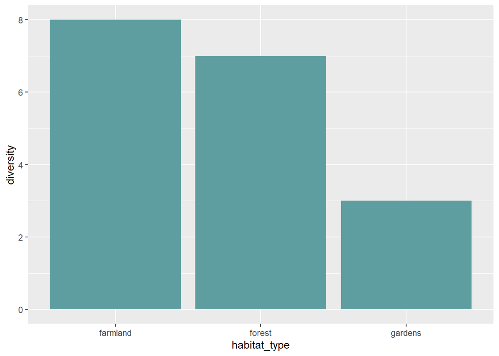

```r
# plot with geom_col

ggplot(bird_data_diversity, aes(x = habitat_type, y = diversity))+
geom_col(fill = "cadetblue")
```

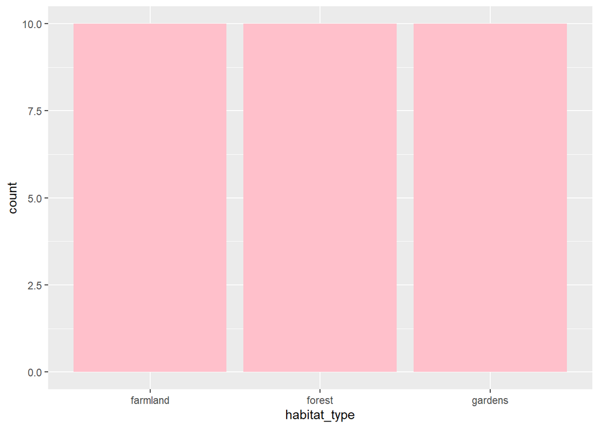

```r
# note, what happens if we use geom_bar with the original data?

ggplot(bird_data, aes(x = habitat_type))+
geom_bar(fill = "pink")
```

## Chi-squared tests

In practicals 1-4 you have learned the basic of data analysis in R, and learned how to conduct and interpret statistical tests that look at **differences in means between categorical groups** (e.g., t-tests, ANOVAs), and those that test for **correlations between two numerical variables** (e.g., Pearson’s correlation). You also had the option to conduct more advanced multi-variate models, General Linear Models.

In this practical you will learn about **Chi-squarest tests**, which tests for differences in expected **frequencies** (or counts) between groups.

Above you made a barplot visualising bird diversity across the three habitat types. Since you can only make a bar plot, then the only statistical test you can do on this data is a Chi-squared test:

[figure not shown]

Since you only have three numbers of work with (8, 7, and 3), you can’t make a histogram of your data, or do a shapiro test. You just have too few data points!

A chi square test tests whether the observed counts across habitats (farmland = 8, woodland = 7, garden = 3) are significantly different to what would be expected due to chance (total 18 species divided by 3 habitats = 6):

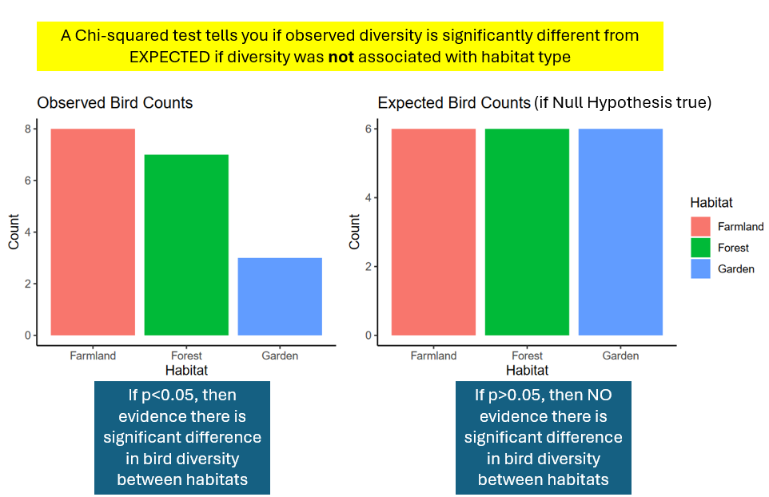

However, the exact code depends on how you have formatted the data, and whether you are performing a **one-way** or **two-way** chi squared test.

- **One way chi squared test**: if you want to know if frequencies differ across just ONE variable
- **Two-way chi-squared test**: If you want to know if frequencies differ across TWO variables.

### Formatting data for Chi-squared tests

Unlike all the other statistical tests you’ve done so far (and will do in the future), where you have one row per observation, the data format for a chi-square test is unique. This is because it is styled on what you would do in Excel, and indeed many people just do chi-squared tests in Excel.

The format generally needed for a hypothetical one-way and two-way chi-squared tests is below:

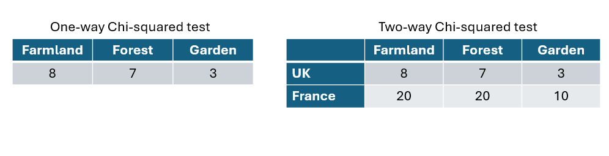

Note for the two-way Chi-squared test you have an additional variable to consider: Country.

However, the problem with this is that in real life, you rarely are able to make a nice frequency table without first manipulating the raw data into the right format. We are therefore going to do this in R.

### One-way chi-squared tests

In our bird example, we want to know if bird diversity differs between habitat type (just one variable). **So we need a one-way chi-squared test.** Notice the three different data formats for count data below and the code to perform a one-way chi-squared test.

Unlike all the models (=statisctial tests) we have fitted so far (where we have one row per observation), chisq.test() would preferably like the data in the middle format in the picture below (multiple observations per row):

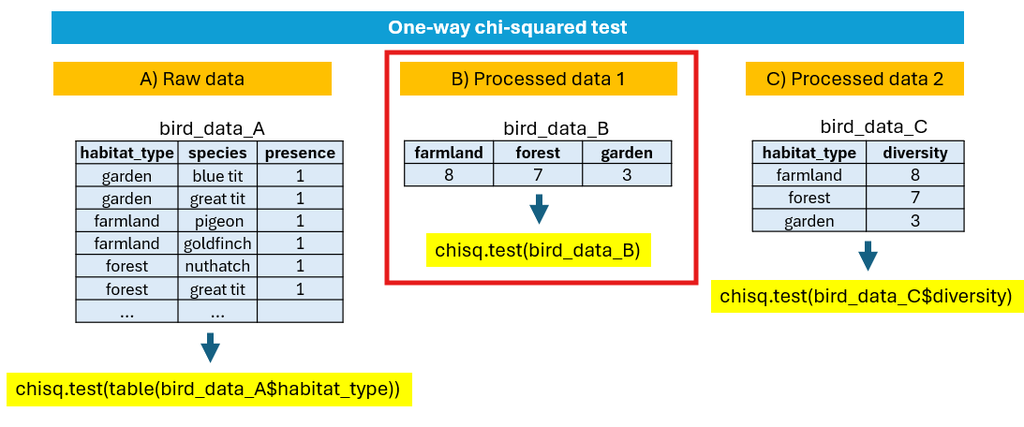

### Remove zeros

Before going further, lets remove species that were not seen from our dataset, so that each row represents a unique species seen per habitat.

```r
bird_data_present <- subset(bird_data, presence == 1)

bird_data_present %>%
  group_by(habitat_type) %>%
  summarise(total = n_distinct(species))
```

| habitat_type | total |
| --- | --- |
| farmland | 8 |
| forest | 7 |
| gardens | 3 |

#### Exercise 6

Run the three lines of code below and work out the data format of the three outputs (A, B or C from the picture above) of each one.

```r
bird_data_present
```

|  | habitat_type | species | presence |
| --- | --- | --- | --- |
| 1 | farmland | Great tit | 1 |
| 2 | farmland | Blue tit | 1 |
| 3 | farmland | Wood pigeon | 1 |
| 4 | farmland | Yellowhammer | 1 |
| 5 | farmland | Skylark | 1 |
| 8 | farmland | Greenfinch | 1 |
| 9 | farmland | Goldfinch | 1 |
| 10 | farmland | Starling | 1 |
| 11 | forest | Great tit | 1 |
| 12 | forest | Blue tit | 1 |

[output cut: 8 more lines]

```r
table(bird_data_present$habitat_type)
```

```
##
## farmland   forest  gardens
##        8        7        3
```

```r
bird_data_diversity
```

| habitat_type | diversity |
| --- | --- |
| farmland | 8 |
| forest | 7 |
| gardens | 3 |

**ANSWER:**

**bird_data_present = Format A**

**bird_data_diversity = Format C**

Lets plot a barplot again and perform a chi-squared test to see if there is significant difference in diversity between three habitats. Notice how the format of the data changes how we would code the bar plot AND the chi squared test.

```r
head(bird_data_present) # one row per species per habitat
```

|  | habitat_type | species | presence |
| --- | --- | --- | --- |
| 1 | farmland | Great tit | 1 |
| 2 | farmland | Blue tit | 1 |
| 3 | farmland | Wood pigeon | 1 |
| 4 | farmland | Yellowhammer | 1 |
| 5 | farmland | Skylark | 1 |
| 8 | farmland | Greenfinch | 1 |

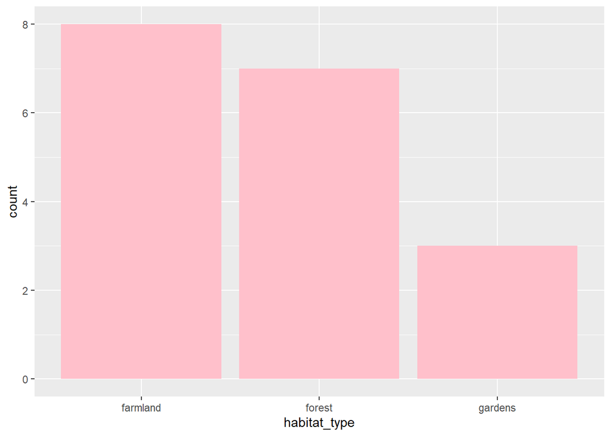

```r
ggplot(bird_data_present, aes(x = habitat_type)) + geom_bar(fill = "pink")
```

```r
chisq.test(table(bird_data_present$habitat_type))
```

```
##
##  Chi-squared test for given probabilities
##
## data:  table(bird_data_present$habitat_type)
## X-squared = 2.3333, df = 2, p-value = 0.3114
```

You could have also done a chi-squared test on the summarised dataset:

```r
bird_data_diversity
```

| habitat_type | diversity |
| --- | --- |
| farmland | 8 |
| forest | 7 |
| gardens | 3 |

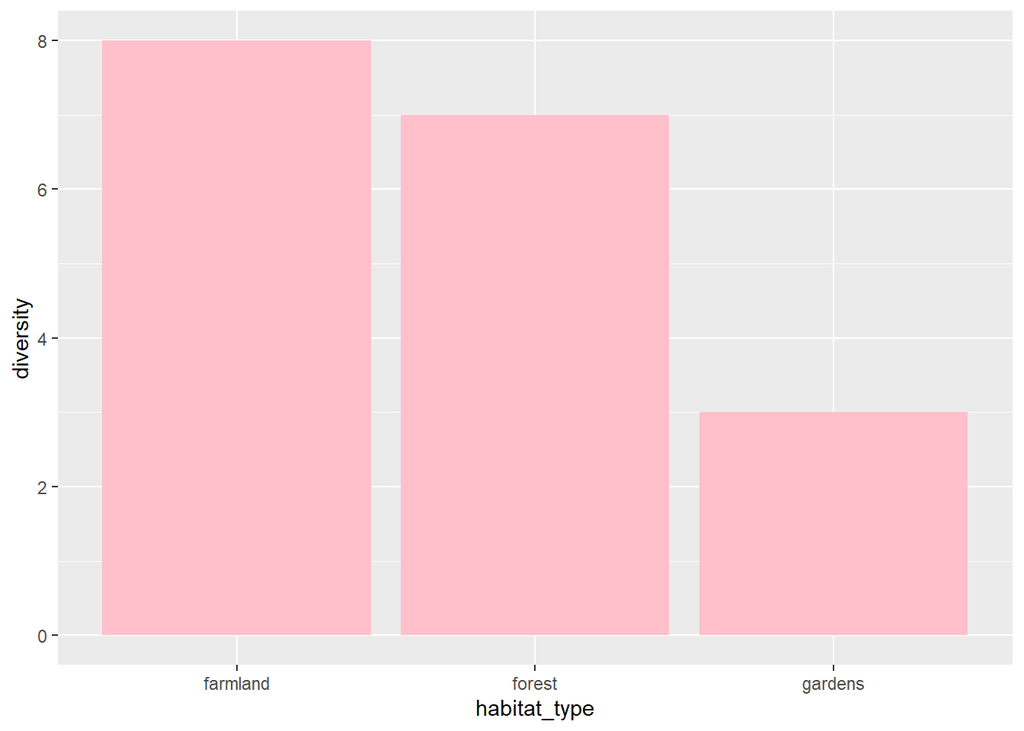

```r
ggplot(bird_data_diversity, aes(x = habitat_type, y = diversity)) + geom_col(fill = "pink")
```

```r
chisq.test(bird_data_diversity$diversity)
```

```
##
##  Chi-squared test for given probabilities
##
## data:  bird_data_diversity$diversity
## X-squared = 2.3333, df = 2, p-value = 0.3114
```

Note that the answer is exactly the same in both cases.

IMPORTANT: **chisq.test(table(bird_data_present$habitat_type))** only works because the number of rows per habitat is the same as the species diversity per habitat. If this was NOT the case (e.g., if you had not removed the zeros), doing a chi-squared test on your raw data would not be appropriate.

#### Exercise 7

Based on the chi-squared test above, write a results section on whether there is a significant difference in bird diversity between the three habitat, including the relevant information in brackets (test name, effects size, and p value).

*ANSWER: Although bird diversity was highest in farmland and forest (8 species and 7 species, respectively) than garden (3 species), this difference was not statistcially significant (Chi-squared test, X-squared = 2.33, p = 0.31).*

## Q1) Allele frequency in reef damselfish

Next we you going to learn how to do a **two-way chi squared test.**

You are a fish biologist studying gene frequencies linked to colour polymorphism in relation to coral health in tropical reef ecosystems.

You study a species of damsel fish that can either be blue, yellow, or white depending on what dominant allele is it carrying (A, B, or C).

*You think that coral bleaching due to climate change may be changing the allele frequency of fish to promote white/pale variants, because white morphs would be better camouflaged against bleached corals and would therefore have a survival advantage.*

- **Allele A = mainly blue colouration**
- **Allele B = mainly yellow colouration**
- **Allele C = mainly white/pale colouration**

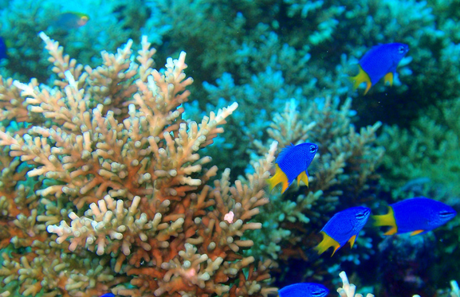

**Methods:** You collect data across two sites - one site is a healthy (colourful) coral reef, and another site has a lot of coral bleaching. You collect 30 damsel fish at each of the two sites and record which allele they have.

Lets go through our normal data analysis steps.

#### Exercise 8

Step 1: Write your null and alternative hypotheses using IF/THEN statement. Note - it’s usually easier to write the alternative hypothesis first.

*ANSWER:*

*NULL: If damselfish colour doesn’t influence survival, I expect there to be no difference in allele frequencies between healthy and bleached coral reefs.*

*ALTERNATIVE: If pale morphs have a survival advantage in bleached reefs, I expect Allele C to be more frequent in bleached reefs compared to healthy reefs, and Alleles A and B to be more frequent in healthy reefs.*

## Copy data into Excel and import into R

#### Exercise 9

- Copy the data below and paste it into excel.
- Save the file as a .csv file, not an excel file (.csv files are more simple text files and do not have multiple tabs on the bottom).
- Save the file as **fish_data.csv** in an appropriately named OneDrive folder.
- Import into R using either the upload and import buttons on the right, or by running:

fish_data<- read.csv(“my_pathway/fish_data.csv”)

Making sure the pathway is linked to where you saved the data.

**NOTE: if you save your data as an excel file (.xlxs), then this is still ok, but make sure you only have one tab and you have to import it via the ‘Import dataset’ button and then selecting the ‘From Excel’ option on the menu.**

| fish_ID | reef_type | allele | Count |
| --- | --- | --- | --- |
| 1 | Healthy | Allele B (Yellow) | 1 |
| 2 | Healthy | Allele B (Yellow) | 1 |
| 3 | Healthy | Allele B (Yellow) | 1 |
| 4 | Healthy | Allele A (Blue) | 1 |
| 5 | Healthy | Allele A (Blue) | 1 |
| 6 | Healthy | Allele B (Yellow) | 1 |
| 7 | Healthy | Allele B (Yellow) | 1 |
| 8 | Healthy | Allele A (Blue) | 1 |
| 9 | Healthy | Allele A (Blue) | 1 |
| 10 | Healthy | Allele B (Yellow) | 1 |
| 11 | Healthy | Allele C (White) | 1 |
| 12 | Healthy | Allele B (Yellow) | 1 |
| 13 | Healthy | Allele A (Blue) | 1 |
| 14 | Healthy | Allele C (White) | 1 |
| 15 | Healthy | Allele A (Blue) | 1 |
| 16 | Healthy | Allele C (White) | 1 |
| 17 | Healthy | Allele A (Blue) | 1 |
| 18 | Healthy | Allele C (White) | 1 |
| 19 | Healthy | Allele B (Yellow) | 1 |
| 20 | Healthy | Allele B (Yellow) | 1 |
| 21 | Healthy | Allele A (Blue) | 1 |
| 22 | Healthy | Allele A (Blue) | 1 |
| 23 | Healthy | Allele B (Yellow) | 1 |
| 24 | Healthy | Allele B (Yellow) | 1 |
| 25 | Healthy | Allele C (White) | 1 |
| 26 | Healthy | Allele A (Blue) | 1 |
| 27 | Healthy | Allele B (Yellow) | 1 |
| 28 | Healthy | Allele A (Blue) | 1 |
| 29 | Healthy | Allele A (Blue) | 1 |
| 30 | Healthy | Allele A (Blue) | 1 |
| 31 | Bleached | Allele C (White) | 1 |
| 32 | Bleached | Allele B (Yellow) | 1 |
| 33 | Bleached | Allele C (White) | 1 |
| 34 | Bleached | Allele B (Yellow) | 1 |
| 35 | Bleached | Allele A (Blue) | 1 |
| 36 | Bleached | Allele C (White) | 1 |
| 37 | Bleached | Allele B (Yellow) | 1 |
| 38 | Bleached | Allele C (White) | 1 |
| 39 | Bleached | Allele C (White) | 1 |
| 40 | Bleached | Allele C (White) | 1 |
| 41 | Bleached | Allele C (White) | 1 |
| 42 | Bleached | Allele C (White) | 1 |
| 43 | Bleached | Allele C (White) | 1 |
| 44 | Bleached | Allele C (White) | 1 |
| 45 | Bleached | Allele B (Yellow) | 1 |
| 46 | Bleached | Allele C (White) | 1 |
| 47 | Bleached | Allele A (Blue) | 1 |
| 48 | Bleached | Allele B (Yellow) | 1 |
| 49 | Bleached | Allele B (Yellow) | 1 |
| 50 | Bleached | Allele C (White) | 1 |
| 51 | Bleached | Allele B (Yellow) | 1 |
| 52 | Bleached | Allele C (White) | 1 |
| 53 | Bleached | Allele A (Blue) | 1 |
| 54 | Bleached | Allele A (Blue) | 1 |
| 55 | Bleached | Allele C (White) | 1 |
| 56 | Bleached | Allele A (Blue) | 1 |
| 57 | Bleached | Allele A (Blue) | 1 |
| 58 | Bleached | Allele C (White) | 1 |
| 59 | Bleached | Allele A (Blue) | 1 |
| 60 | Bleached | Allele B (Yellow) | 1 |

You should now have fish_data in your working environment. Run the following code and check the output looks the same.

```r
head(fish_data)
```

|  | fish_ID | reef_type | allele | count |
| --- | --- | --- | --- | --- |
| 1 | 1 | Healthy | Allele B (Yellow) | 1 |
| 2 | 2 | Healthy | Allele B (Yellow) | 1 |
| 3 | 3 | Healthy | Allele B (Yellow) | 1 |
| 4 | 4 | Healthy | Allele A (Blue) | 1 |
| 5 | 5 | Healthy | Allele A (Blue) | 1 |
| 6 | 6 | Healthy | Allele B (Yellow) | 1 |

```r
dim(fish_data)
```

```
## [1] 60  4
```

```r
str(fish_data)
```

```
## 'data.frame':    60 obs. of  4 variables:
##  $ fish_ID  : int  1 2 3 4 5 6 7 8 9 10 ...
##  $ reef_type: chr  "Healthy" "Healthy" "Healthy" "Healthy" ...
##  $ allele   : chr  "Allele B (Yellow)" "Allele B (Yellow)" "Allele B (Yellow)" "Allele A (Blue)" ...
##  $ count    : int  1 1 1 1 1 1 1 1 1 1 ...
```

#### Exercise 10

Each row in this dataset represents an individual fish that was caught and genotyped. If you wanted to summarise how many fish had each allele per habitat, which functions out of the bellow would you need? (two would work).

| Summary statistic | Function |
| --- | --- |
| Maximum | max() |
| Minimim | min() |
| Mean | mean() |
| Median | median() |
| Standard deviation | sd() |
| Sum | sum() |
| Number of observations | n() |
| Number of unique observations | n_distinct() |
| Keep only unique observations | unique() |

*ANSWER: n() or sum()*

#### Exercise 11

Out of the plots below, which one do you think visualises the data the best, given your ultimate goal of understanding whether the distribution of alleles is different between bleached and healthy habitats? All plots are theoretically correct, but some are better than others at visualising the data.

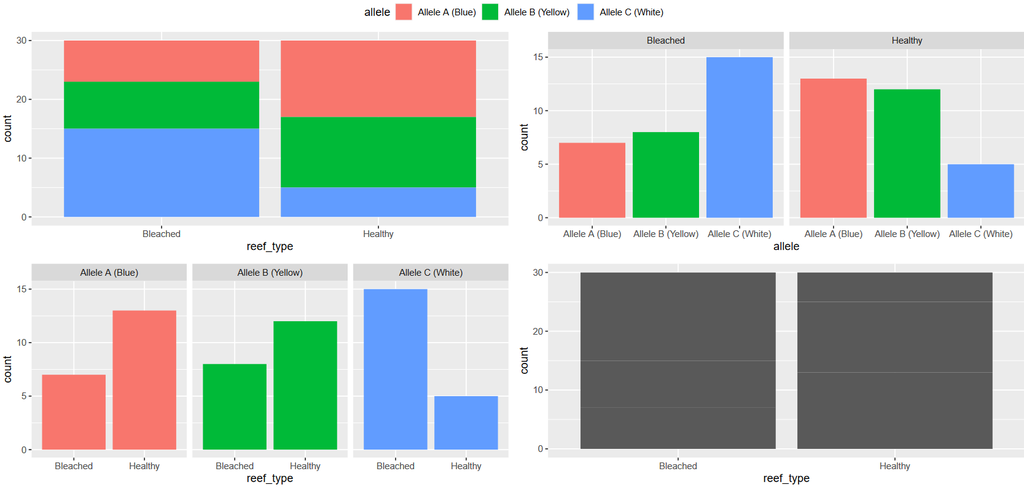

*ANSWER: I would say wither top right if you want to emphasize differences in allele composition between habitats, or bottom left if you want to emphasize differences in frequencies between specific alleles.*

#### Exercise 12

**Step 2: Plot the number of fish with alleles A, B and C across the two habitats. Try and make the plot you chose above.**

Guidance: There are a number of ways you can do this, but first you need to use dplyr package to summarise how many fish have each allele in each habitat. You want as an output the following table:

| Reef_type | Allele | Count |
| --- | --- | --- |
| Healthy | A | ? |
| Healthy | B | ? |
| Healthy | C | ? |
| Bleached | A | ? |
| Bleached | B | ? |
| Bleached | C | ? |

Because each row represents one fish, you just need to count the number of rows per reef type and per allele using n(). You should identified this as the correct function in Exercise 10 above.

**allele_freq <- fish_data %>% group_by(? , ?) %>% summarise(total = sum(count))**

OR

**allele_freq <- fish_data %>% group_by(? , ?) %>% summarise(total = n())**

You then can use geom_col() to make a bar plot:

**ggplot(allele_freq, aes(x = ?, y = ?, fill = ?)) + geom_col() + facet_wrap(~?)**

```r
head(fish_data)
```

|  | fish_ID | reef_type | allele | count |
| --- | --- | --- | --- | --- |
| 1 | 1 | Healthy | Allele B (Yellow) | 1 |
| 2 | 2 | Healthy | Allele B (Yellow) | 1 |
| 3 | 3 | Healthy | Allele B (Yellow) | 1 |
| 4 | 4 | Healthy | Allele A (Blue) | 1 |
| 5 | 5 | Healthy | Allele A (Blue) | 1 |
| 6 | 6 | Healthy | Allele B (Yellow) | 1 |

```r
allele_freq<-fish_data %>%
  group_by(reef_type, allele) %>%
  summarise(total = sum(count))
allele_freq
```

| reef_type | allele | total |
| --- | --- | --- |
| Bleached | Allele A (Blue) | 7 |
| Bleached | Allele B (Yellow) | 8 |
| Bleached | Allele C (White) | 15 |
| Healthy | Allele A (Blue) | 13 |
| Healthy | Allele B (Yellow) | 12 |
| Healthy | Allele C (White) | 5 |

```r
# or


allele_freq<-fish_data %>%
  group_by(reef_type, allele) %>%
  summarise(total = n())
####

allele_freq
```

| reef_type | allele | total |
| --- | --- | --- |
| Bleached | Allele A (Blue) | 7 |
| Bleached | Allele B (Yellow) | 8 |
| Bleached | Allele C (White) | 15 |
| Healthy | Allele A (Blue) | 13 |
| Healthy | Allele B (Yellow) | 12 |
| Healthy | Allele C (White) | 5 |

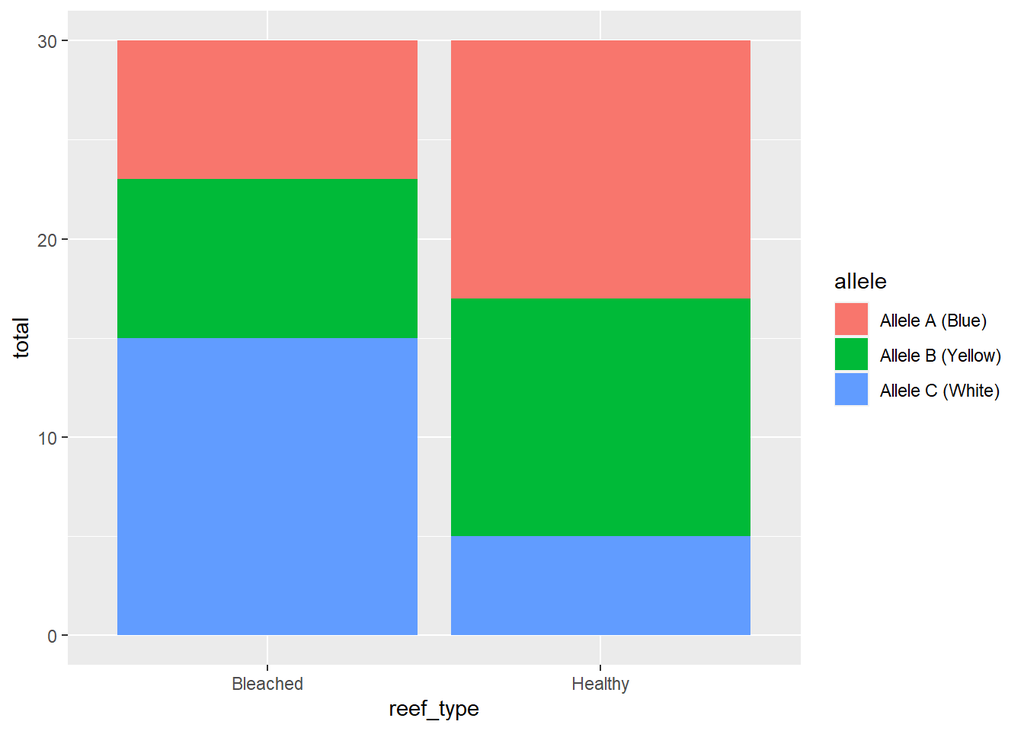

```r
# making a barplot

# option 1

ggplot(allele_freq, aes(x = reef_type, y = total, fill = allele))+
  geom_col()
```

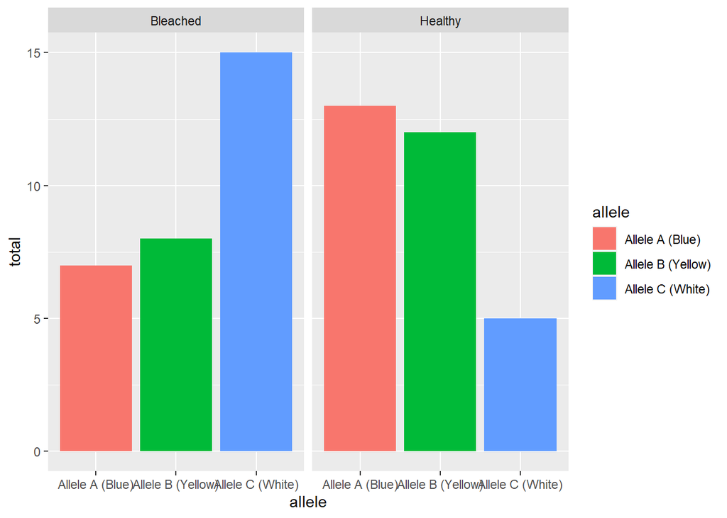

```r
# option 2

ggplot(allele_freq, aes(x = allele, y = total, fill = allele))+
  geom_col()+
  facet_wrap(~reef_type)
```

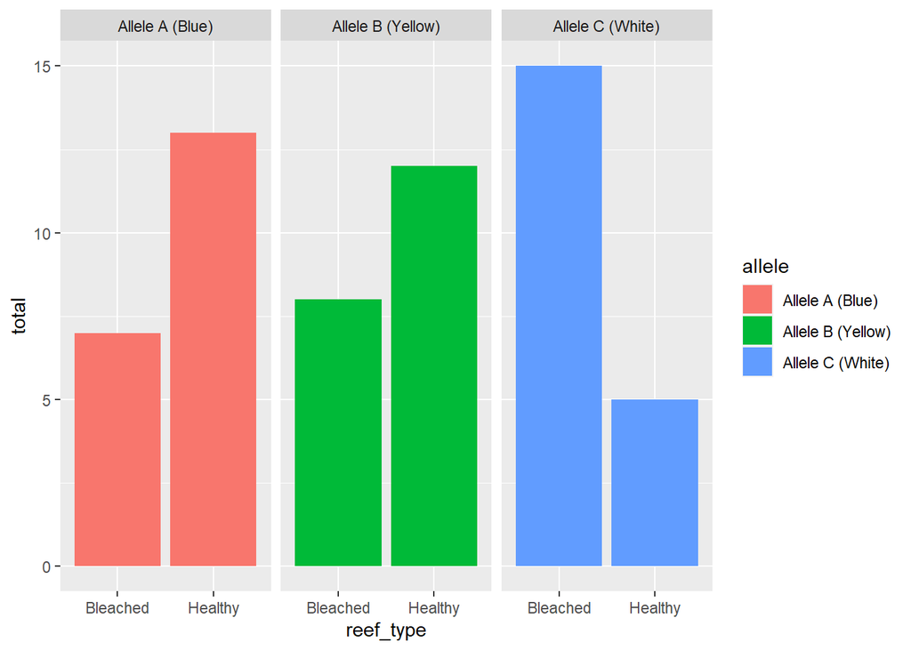

```r
# option 3

ggplot(allele_freq, aes(x = reef_type, y = total, fill = allele))+
  geom_col()+
  facet_wrap(~allele)
```

```r
# Personally I think option 2 is the best for visualising differences in allele frequency between the two habitats
```

**Step 3: Test your numerical data for normality.**

Nope - you don’t need to do this as if you have made any sort of bar plot, you don’t have enough data to test for normality:

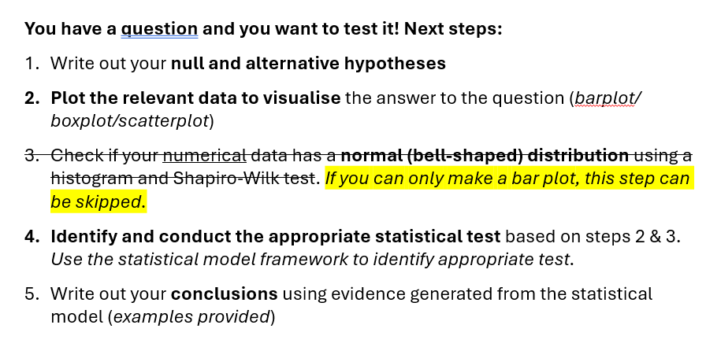

You only need to check if your numerical data has a normal distribution or not is you have made a boxplot or a scatter plot for step 2.

## Two-way Chi-squared tests

You have made a barplot, which means you will need a chi-squared test. But do you need a one-way chi-squared test of a two-way chi-squared test?

Unlike with the bird example, where you just linked species counts to habitat type, in this example you want to link allele counts to reef type (healthy/bleached) AND allele variant (A, B, or C). So you need a two way chi-squared test.

See the picture for how to do this. As with a one-way Chi-squared test, ideally you want the data to be in the middle format first.

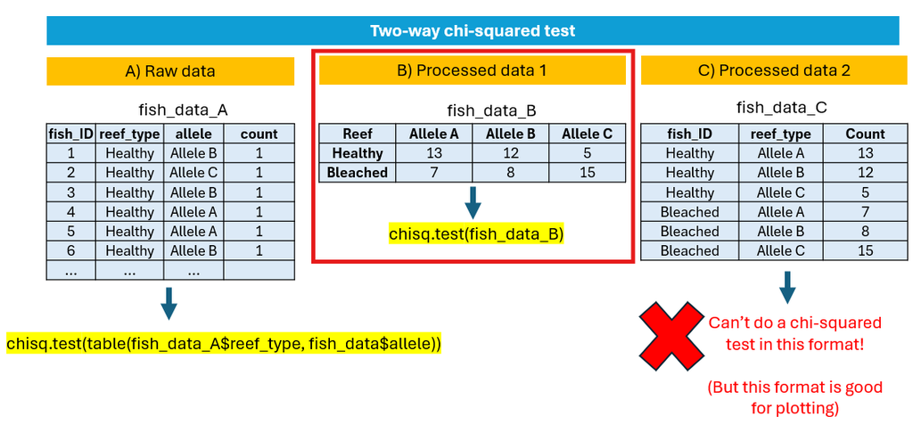

#### Exercise 13

Conduct a two-way Chi-square test on your data using the following code. Note: Lets save our chi-squared model as an object called ‘Xsq’ so we can look at it in more depth.

```r
fish_data_B <- table(fish_data$reef_type, fish_data$allele)

fish_data_B
```

```
##
##            Allele A (Blue) Allele B (Yellow) Allele C (White)
##   Bleached               7                 8               15
##   Healthy               13                12                5
```

```r
(Xsq <-  chisq.test(fish_data_B)) # save model as 'Xsq'
```

```
##
##  Pearson's Chi-squared test
##
## data:  fish_data_B
## X-squared = 7.6, df = 2, p-value = 0.02237
```

One of the useful thing about saving models as objects is that you can look under the hood. In this case, the chi-squared model contains information on not only the observed data, but also the expected data distribution if the null hypothesis was true:

```r
str(Xsq)
```

```
## List of 9
##  $ statistic: Named num 7.6
##   ..- attr(*, "names")= chr "X-squared"
##  $ parameter: Named int 2
##   ..- attr(*, "names")= chr "df"
##  $ p.value  : num 0.0224
##  $ method   : chr "Pearson's Chi-squared test"
##  $ data.name: chr "fish_data_B"
##  $ observed : 'table' int [1:2, 1:3] 7 13 8 12 15 5
##   ..- attr(*, "dimnames")=List of 2
##   .. ..$ : chr [1:2] "Bleached" "Healthy"
##   .. ..$ : chr [1:3] "Allele A (Blue)" "Allele B (Yellow)" "Allele C (White)"
##  $ expected : num [1:2, 1:3] 10 10 10 10 10 10
##   ..- attr(*, "dimnames")=List of 2
##   .. ..$ : chr [1:2] "Bleached" "Healthy"
##   .. ..$ : chr [1:3] "Allele A (Blue)" "Allele B (Yellow)" "Allele C (White)"
##  $ residuals: 'table' num [1:2, 1:3] -0.949 0.949 -0.632 0.632 1.581 ...
##   ..- attr(*, "dimnames")=List of 2
##   .. ..$ : chr [1:2] "Bleached" "Healthy"
##   .. ..$ : chr [1:3] "Allele A (Blue)" "Allele B (Yellow)" "Allele C (White)"
##  $ stdres   : 'table' num [1:2, 1:3] -1.64 1.64 -1.1 1.1 2.74 ...
##   ..- attr(*, "dimnames")=List of 2
##   .. ..$ : chr [1:2] "Bleached" "Healthy"
##   .. ..$ : chr [1:3] "Allele A (Blue)" "Allele B (Yellow)" "Allele C (White)"
##  - attr(*, "class")= chr "htest"
```

```r
Xsq$observed
```

```
##
##            Allele A (Blue) Allele B (Yellow) Allele C (White)
##   Bleached               7                 8               15
##   Healthy               13                12                5
```

```r
Xsq$expected
```

```
##
##            Allele A (Blue) Allele B (Yellow) Allele C (White)
##   Bleached              10                10               10
##   Healthy               10                10               10
```

#### Exercise 14

How many blue, yellow, and white morphs would you expect in each reef type if the null hypothesis was true?

*ANSWER: 10 per group.*

#### Exercise 15

Your original goal was to identify whether pale variants (allele C) increased in bleached habitats. Write 2-3 sentences, drawing from your plots and chi-squared test, on what you conclude.

*ANSWER: Pale damselfish with allele C are significantly more common in bleached reefs than normal reefs compared to blue and yellow morphs (Two-way chi-squared test, X2 = 7.6, p=0.022, n = 60), with the opposite being true on healthy reefs. This suggests that pale morphs have a survival advantage in bleached reefs compared to blue and yellow morphs.*

## Extra: Arrange data

Sometimes it is helpful to arrange your data so you can easily see the smallest or largest values. To do this, you need the **arrange()** function in **dplyr.** Lets practice this with the worm dataset.

Lets arrange the worm data by both month and worm abundance.

```r
# arrange by month and then worm abundance, both arranged smallest to largest

worm_data %>% arrange(month, worm_abundance)
```

| plot_ID | habitat_type | month | rainfall_mm | worm_diversity | worm_abundance |
| --- | --- | --- | --- | --- | --- |
| 60 | Farmland | 5 | 38.5 | 2 | 14 |
| 54 | Farmland | 5 | 20.5 | 4 | 38 |
| 43 | Farmland | 5 | 12.6 | 5 | 43 |
| 14 | Forest | 5 | 52.5 | 2 | 44 |
| 57 | Farmland | 5 | 75.7 | 2 | 56 |
| 47 | Farmland | 5 | 20.6 | 5 | 61 |
| 40 | Farmland | 5 | 58.1 | 1 | 64 |
| 35 | Farmland | 5 | 66.1 | 5 | 68 |
| 45 | Farmland | 5 | 66.6 | 2 | 70 |
| 21 | Forest | 5 | 31.4 | 4 | 72 |

[output cut: 82 more lines]

```r
# arrange by month and then worm abundance, with worm abundance arranged largest to smallest (only view first 6 rows)

head(worm_data %>% arrange(month, -worm_abundance))
```

|  | plot_ID | habitat_type | month | rainfall_mm | worm_diversity | worm_abundance |
| --- | --- | --- | --- | --- | --- | --- |
| 1 | 6 | Forest | 5 | 79.7 | 8 | 149 |
| 2 | 23 | Forest | 5 | 46.0 | 5 | 138 |
| 3 | 75 | Garden | 5 | 59.7 | 7 | 134 |
| 4 | 80 | Garden | 5 | 68.9 | 4 | 133 |
| 5 | 73 | Garden | 5 | 59.5 | 2 | 131 |
| 6 | 5 | Forest | 5 | 47.2 | 2 | 129 |

#### Exercise 16

Arrange the dataset by habitat and then worm diversity. From looking at your rearranged data, what is the highest worm diversity in Farmland habitat?

```r
head(worm_data %>% arrange(habitat_type, -worm_diversity))
```

|  | plot_ID | habitat_type | month | rainfall_mm | worm_diversity | worm_abundance |
| --- | --- | --- | --- | --- | --- | --- |
| 1 | 34 | Farmland | 6 | 56.0 | 8 | 119 |
| 2 | 56 | Farmland | 5 | 61.8 | 8 | 114 |
| 3 | 36 | Farmland | 6 | 37.8 | 7 | 90 |
| 4 | 52 | Farmland | 7 | 53.0 | 7 | 121 |
| 5 | 35 | Farmland | 5 | 66.1 | 5 | 68 |
| 6 | 43 | Farmland | 5 | 12.6 | 5 | 43 |

```r
# ANSWER: highest in farmland is 8 species of worms.
```

## Extra: Make a new column in your dataset

Lets make a new column that categorises whether worms are present or not at the plot. Since all plots found at least some worms, we can just put a ‘1’ in all rows of our new column.

```r
worm_data$presence <- 1 # Make a new column called 'Presence' and make all values 1

head(worm_data)
```

|  | plot_ID | habitat_type | month | rainfall_mm | worm_diversity | worm_abundance | presence |
| --- | --- | --- | --- | --- | --- | --- | --- |
| 1 | 1 | Forest | 6 | 47.1 | 4 | 121 | 1 |
| 2 | 2 | Forest | 6 | 32.1 | 2 | 70 | 1 |
| 3 | 3 | Forest | 7 | 54.0 | 1 | 55 | 1 |
| 4 | 4 | Forest | 7 | 39.3 | 4 | 102 | 1 |
| 5 | 5 | Forest | 5 | 47.2 | 2 | 129 | 1 |
| 6 | 6 | Forest | 5 | 79.7 | 8 | 149 | 1 |

However, in most cases we want to make a new column that is dependent on the value of another column. In this case it is often useful to use the function ifelse().

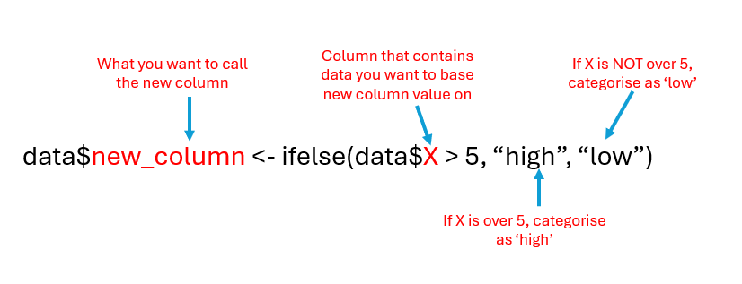

```r
head(worm_data)
```

|  | plot_ID | habitat_type | month | rainfall_mm | worm_diversity | worm_abundance | presence |
| --- | --- | --- | --- | --- | --- | --- | --- |
| 1 | 1 | Forest | 6 | 47.1 | 4 | 121 | 1 |
| 2 | 2 | Forest | 6 | 32.1 | 2 | 70 | 1 |
| 3 | 3 | Forest | 7 | 54.0 | 1 | 55 | 1 |
| 4 | 4 | Forest | 7 | 39.3 | 4 | 102 | 1 |
| 5 | 5 | Forest | 5 | 47.2 | 2 | 129 | 1 |
| 6 | 6 | Forest | 5 | 79.7 | 8 | 149 | 1 |

```r
mean(worm_data$worm_abundance) # return the mean count
```

```
## [1] 95.04348
```

```r
worm_data$High_or_low <- ifelse(worm_data$worm_abundance > 95, "High", "Low")


head(worm_data)# notice new column on the right
```

|  | plot_ID | habitat_type | month | rainfall_mm | worm_diversity | worm_abundance | presence | High_or_low |
| --- | --- | --- | --- | --- | --- | --- | --- | --- |
| 1 | 1 | Forest | 6 | 47.1 | 4 | 121 | 1 | High |
| 2 | 2 | Forest | 6 | 32.1 | 2 | 70 | 1 | Low |
| 3 | 3 | Forest | 7 | 54.0 | 1 | 55 | 1 | Low |
| 4 | 4 | Forest | 7 | 39.3 | 4 | 102 | 1 | High |
| 5 | 5 | Forest | 5 | 47.2 | 2 | 129 | 1 | High |
| 6 | 6 | Forest | 5 | 79.7 | 8 | 149 | 1 | High |

Lets make another new column that categorises whether the plot is in farmland or not:

```r
worm_data$farmland <- ifelse(worm_data$habitat_type=="Farmland", "yes", "no")

head(worm_data, 20)
```

|  | plot_ID | habitat_type | month | rainfall_mm | worm_diversity | worm_abundance | presence | High_or_low | farmland |
| --- | --- | --- | --- | --- | --- | --- | --- | --- | --- |
| 1 | 1 | Forest | 6 | 47.1 | 4 | 121 | 1 | High | no |
| 2 | 2 | Forest | 6 | 32.1 | 2 | 70 | 1 | Low | no |
| 3 | 3 | Forest | 7 | 54.0 | 1 | 55 | 1 | Low | no |
| 4 | 4 | Forest | 7 | 39.3 | 4 | 102 | 1 | High | no |
| 5 | 5 | Forest | 5 | 47.2 | 2 | 129 | 1 | High | no |
| 6 | 6 | Forest | 5 | 79.7 | 8 | 149 | 1 | High | no |
| 7 | 7 | Forest | 7 | 60.7 | 3 | 140 | 1 | High | no |
| 8 | 8 | Forest | 6 | 26.4 | 2 | 112 | 1 | High | no |
| 9 | 9 | Forest | 5 | 66.0 | 5 | 113 | 1 | High | no |
| 10 | 10 | Forest | 7 | 90.9 | 6 | 109 | 1 | High | no |

[output cut: 10 more lines]

#### Exercise 17

Make a new column in your dataset called ‘high_diversity_site’, and this column represents whether the plot had higher species diversity than average. If the site has higher diversity than average, the new column should have a ‘yes’, and if lower than average, it should have a ‘no’. Check your column is correctly formatted by looking at the new column.

```r
worm_data$high_diversity_site <- ifelse(worm_data$worm_diversity > mean(worm_data$worm_diversity), "yes", "no")

head(worm_data)
```

|  | plot_ID | habitat_type | month | rainfall_mm | worm_diversity | worm_abundance | presence | High_or_low | farmland | high_diversity_site |
| --- | --- | --- | --- | --- | --- | --- | --- | --- | --- | --- |
| 1 | 1 | Forest | 6 | 47.1 | 4 | 121 | 1 | High | no | yes |
| 2 | 2 | Forest | 6 | 32.1 | 2 | 70 | 1 | Low | no | no |
| 3 | 3 | Forest | 7 | 54.0 | 1 | 55 | 1 | Low | no | no |
| 4 | 4 | Forest | 7 | 39.3 | 4 | 102 | 1 | High | no | yes |
| 5 | 5 | Forest | 5 | 47.2 | 2 | 129 | 1 | High | no | no |
| 6 | 6 | Forest | 5 | 79.7 | 8 | 149 | 1 | High | no | yes |

## Extra: Remove missing data

Datasets often have missing data, which can interfere with analyses. If you want to remove missing data, I have added how to do this below using either **na.omit()** or the **subset()** function.

First, lets upload the penguin dataset from the palmerpenguin package, as this has missing data.

```r
library(palmerpenguins)
data(penguins)

head(penguins) # notice missing data in row 4
```

| species | island | bill_length_mm | bill_depth_mm | flipper_length_mm | body_mass_g | sex | year |
| --- | --- | --- | --- | --- | --- | --- | --- |
| Adelie | Torgersen | 39.1 | 18.7 | 181 | 3750 | male | 2007 |
| Adelie | Torgersen | 39.5 | 17.4 | 186 | 3800 | female | 2007 |
| Adelie | Torgersen | 40.3 | 18.0 | 195 | 3250 | female | 2007 |
| Adelie | Torgersen | NA | NA | NA | NA | NA | 2007 |
| Adelie | Torgersen | 36.7 | 19.3 | 193 | 3450 | female | 2007 |
| Adelie | Torgersen | 39.3 | 20.6 | 190 | 3650 | male | 2007 |

```r
# remove all rows with any missing data anywhere
penguins1 <-na.omit(penguins)

# remove rows with missing data just in body_mass_g column

penguins2 <- subset(penguins, !is.na(body_mass_g))
```

## Extra: Get help on how a function works

Not sure how a function works? Use the help function, or ?function().

A help page will come up which will tell you what arguments you need to put inside the brackets.

**Scroll down to find “Examples” and copy and paste the code into a new R script.** This will provide working examples of how the function works.

```r
help(cor.test)
```

```
## starting httpd help server ... done
```

```r
?chisq.test

?geom_bar()
```

## Extra: Install R and R studio software

Important: The free version of R studio cloud only provides so many free hours per month. If you think you will exceed this, it is worth downloading R and R studio software. The software looks almost identical to the cloud version you have been using.

To install R Studio, you need to install both:

- R https://cran.r-project.org/
- R Studio https://posit.co/download/rstudio-desktop/ (you can do both steps from this link).

[figure not shown]

R is the R language software, whilst R Studio is the user interface. Once you have downloaded both, you only ever need to open **R Studio**, not R.

**If you want to keep all the work you’ve done so far, you can download your whole R Studio cloud project on to your computer by pressing the ‘Export’ button next to the project you want to download (which should be called “R workshop”), and then open it with your R Studio software.**

[figure not shown]

This will download all your scripts and R data in one file, and you can open it by clicking on the downloaded R studio project icon, which should be called “**R workshop.Rproj**”.

**NOTE: You can just code in R, without using the user interface R Studio.** If you are doing Joe Jackson’s Data Science module next semester, you may use R without R Studio. It is your choice - if you feel more comfortable using R studio, please use it.

## Additional resources to continue in R

There are countless resources out there to learn R. Everyone needs to proactice in their own time if they are to get confident. This course is just a taster. Here are a few links to other resources:

R Studio basics: https://posit.cloud/learn/recipes

R Cookbook: https://rc2e.com/

R for Data Science: https://r4ds.hadley.nz/

Plotting with ggplot2: https://r-graph-gallery.com/ggplot2-package.html